# Project Python Foundations: FoodHub Data Analysis

### Context

The number of restaurants in New York is increasing day by day. Lots of students and busy professionals rely on those restaurants due to their hectic lifestyles. Online food delivery service is a great option for them. It provides them with good food from their favorite restaurants. A food aggregator company FoodHub offers access to multiple restaurants through a single smartphone app.

The app allows the restaurants to receive a direct online order from a customer. The app assigns a delivery person from the company to pick up the order after it is confirmed by the restaurant. The delivery person then uses the map to reach the restaurant and waits for the food package. Once the food package is handed over to the delivery person, he/she confirms the pick-up in the app and travels to the customer's location to deliver the food. The delivery person confirms the drop-off in the app after delivering the food package to the customer. The customer can rate the order in the app. The food aggregator earns money by collecting a fixed margin of the delivery order from the restaurants.

### Objective

The food aggregator company has stored the data of the different orders made by the registered customers in their online portal. They want to analyze the data to get a fair idea about the demand of different restaurants which will help them in enhancing their customer experience. Suppose you are hired as a Data Scientist in this company and the Data Science team has shared some of the key questions that need to be answered. Perform the data analysis to find answers to these questions that will help the company to improve the business.

### Data Description

The data contains the different data related to a food order. The detailed data dictionary is given below.

### Data Dictionary

- order_id: Unique ID of the order
- customer_id: ID of the customer who ordered the food
- restaurant_name: Name of the restaurant
- cuisine_type: Cuisine ordered by the customer
- cost_of_the_order: Cost of the order
- day_of_the_week: Indicates whether the order is placed on a weekday or weekend (The weekday is from Monday to Friday and the weekend is Saturday and Sunday)
- rating: Rating given by the customer out of 5
- food_preparation_time: Time (in minutes) taken by the restaurant to prepare the food. This is calculated by taking the difference between the timestamps of the restaurant's order confirmation and the delivery person's pick-up confirmation.
- delivery_time: Time (in minutes) taken by the delivery person to deliver the food package. This is calculated by taking the difference between the timestamps of the delivery person's pick-up confirmation and drop-off information

### Let us start by importing the required libraries

```python
# Installing the libraries with the specified version.
!pip install numpy==1.25.2 pandas==1.5.3 matplotlib==3.7.1 seaborn==0.13.1 -q --user
```

**Note**: *After running the above cell, kindly restart the notebook kernel and run all cells sequentially from the start again.*

```python
# import libraries for data manipulation
import numpy as np
import pandas as pd

# import libraries for data visualization
import matplotlib.pyplot as plt
import seaborn as sns
```

### Understanding the structure of the data

```python
#Mounting google drive
from google.colab import drive
drive.mount('/content/drive')
```

```python
!ls '/content/drive/MyDrive/Python_GL_docs'
```

[output not shown]

```python
!jupyter nbconvert --to html /content/drive/MyDrive/Python_GL_docs/Learner_Notebook_Full_Code.ipynb
```

```
[NbConvertApp] Converting notebook /content/drive/MyDrive/Python_GL_docs/Learner_Notebook_Full_Code.ipynb to html
[NbConvertApp] Writing 1747088 bytes to /content/drive/MyDrive/Python_GL_docs/Learner_Notebook_Full_Code.html
```

```python
# Import .csv file of the dataset(Foodhub_order)
foodhub= pd.read_csv('/content/drive/MyDrive/Python_GL_docs/foodhub_order.csv')
```

```python
# 1st 5 rows of the dataset
foodhub.head()
```

|  | order_id | customer_id | restaurant_name | cuisine_type | cost_of_the_order | day_of_the_week | rating | food_preparation_time | delivery_time |
| --- | --- | --- | --- | --- | --- | --- | --- | --- | --- |
| 0 | 1477147 | 337525 | Hangawi | Korean | 30.75 | Weekend | Not given | 25 | 20 |
| 1 | 1477685 | 358141 | Blue Ribbon Sushi Izakaya | Japanese | 12.08 | Weekend | Not given | 25 | 23 |
| 2 | 1477070 | 66393 | Cafe Habana | Mexican | 12.23 | Weekday | 5 | 23 | 28 |
| 3 | 1477334 | 106968 | Blue Ribbon Fried Chicken | American | 29.20 | Weekend | 3 | 25 | 15 |
| 4 | 1478249 | 76942 | Dirty Bird to Go | American | 11.59 | Weekday | 4 | 25 | 24 |

### **Question 1:** How many rows and columns are present in the data? [0.5 mark]

```python
# Finding rows and columns in the dataframe
print("There are", foodhub.shape[0], 'rows and', foodhub.shape[1], "columns in this dataframe.")
```

```
There are 1898 rows and 9 columns in this dataframe.
```

#### Observations:

There are 1898 rows and 9 columns in this dataset.

### **Question 2:** What are the datatypes of the different columns in the dataset? (The info() function can be used) [0.5 mark]

```python
# Finding columns and their datatype in the dataframe
foodhub.info()
```

```
<class 'pandas.core.frame.DataFrame'>
RangeIndex: 1898 entries, 0 to 1897
Data columns (total 9 columns):
 #   Column                 Non-Null Count  Dtype
---  ------                 --------------  -----
 0   order_id               1898 non-null   int64
 1   customer_id            1898 non-null   int64
 2   restaurant_name        1898 non-null   object
 3   cuisine_type           1898 non-null   object
 4   cost_of_the_order      1898 non-null   float64
 5   day_of_the_week        1898 non-null   object
 6   rating                 1898 non-null   object
 7   food_preparation_time  1898 non-null   int64
 8   delivery_time          1898 non-null   int64
dtypes: float64(1), int64(4), object(4)
memory usage: 133.6+ KB
```

#### Observations:

There are a total of 1898 non-null observations in each of the columns.

The dataframe contains 9 columns:

- 1 is of floating point type ('cost_of_the_order').
- 4 are of them are integer type ('order_id', 'customer_id', 'food_preparation_time', 'delivery_time') and
- 4 are of the general object type ('restaurant_name', 'cuisine_type', 'day_of_the_week', 'rating').

Total memory usage is approximately 133.6 KB.

### **Question 3:** Are there any missing values in the data? If yes, treat them using an appropriate method. [1 mark]

```python
# Finding any missing values in the data
foodhub.isnull().sum()
```

|  | 0 |
| --- | --- |
| order_id | 0 |
| customer_id | 0 |
| restaurant_name | 0 |
| cuisine_type | 0 |
| cost_of_the_order | 0 |
| day_of_the_week | 0 |
| rating | 0 |
| food_preparation_time | 0 |
| delivery_time | 0 |

**dtype:** int64

#### Observations:

There is no missing values in the data.

### **Question 4:** Check the statistical summary of the data. What is the minimum, average, and maximum time it takes for food to be prepared once an order is placed? [2 marks]

```python
# Statistical Summary of data
foodhub.describe()
```

|  | order_id | customer_id | cost_of_the_order | food_preparation_time | delivery_time |
| --- | --- | --- | --- | --- | --- |
| count | 1.898000e+03 | 1898.000000 | 1898.000000 | 1898.000000 | 1898.000000 |
| mean | 1.477496e+06 | 171168.478398 | 16.498851 | 27.371970 | 24.161749 |
| std | 5.480497e+02 | 113698.139743 | 7.483812 | 4.632481 | 4.972637 |
| min | 1.476547e+06 | 1311.000000 | 4.470000 | 20.000000 | 15.000000 |
| 25% | 1.477021e+06 | 77787.750000 | 12.080000 | 23.000000 | 20.000000 |
| 50% | 1.477496e+06 | 128600.000000 | 14.140000 | 27.000000 | 25.000000 |
| 75% | 1.477970e+06 | 270525.000000 | 22.297500 | 31.000000 | 28.000000 |
| max | 1.478444e+06 | 405334.000000 | 35.410000 | 35.000000 | 33.000000 |

```python
# Minimum time it takes for food to be prepared once an order is placed
foodhub['food_preparation_time'].min()
```

```
20
```

```python
# Average time it takes for food to be prepared once an order is placed
foodhub['food_preparation_time'].mean()
```

```
27.371970495258168
```

```python
# Maximum time it takes for food to be prepared once an order is placed
foodhub['food_preparation_time'].max()
```

```
35
```

#### Observations:

- Order ID and Customer ID are just identifiers for each order.
- The cost_of_the_order request goes from 4.47 to 35.41 dollars, with an average order costing around 16 dollars and a standard deviation of 7.5 dollars.
- The expense of 75% of the orders are under $23. This shows that most of the clients prefer minimal expense food compared to the costly ones.
- Food_preparation_time ranges from minimum 20 minutes to maximum 35 minutes with an average of aound 27 minutes and a standard deviation of 4.6 minutes.
- Delivery_time ranges from 15 to 33 minutes with an average of 24 minutes and a standard deviation of approximately 5 minutes.

### **Question 5:** How many orders are not rated? [1 mark]

```python
# orders that are not rated
foodhub['rating'].value_counts()
```

| rating | count |
| --- | --- |
| Not given | 736 |
| 5 | 588 |
| 4 | 386 |
| 3 | 188 |

**dtype:** int64

#### Observations:

- There are 4 unique values in the 'rating' column: Not given, 5, 4, 3 and,
- 736 orders are not rated.

### Exploratory Data Analysis (EDA)

### **Question 6:** Explore all the variables and provide observations on their distributions. (Generally, histograms, boxplots, countplots, etc. are used for univariate exploration.) [9 marks]

```python
# 1st variable: order_id
print('Number of unique ID in the order_id column is', foodhub['order_id'].nunique())
```

```
Number of unique ID in the order_id column is 1898
```

```python
# 2nd variable: customer_id
foodhub['customer_id'].nunique()
```

```
1200
```

##### Observation:

There are 1200 unique customers. Since the variable 'customer_id' denotes the number of customers, and the number of unique ID in order_id is more than the number of customer_id that means there are some customers who have ordered more than once.

```python
# 3rd variable: restaurant_name
foodhub['restaurant_name'].nunique()
foodhub['restaurant_name'].value_counts()
```

| restaurant_name | count |
| --- | --- |
| Shake Shack | 219 |
| The Meatball Shop | 132 |
| Blue Ribbon Sushi | 119 |
| Blue Ribbon Fried Chicken | 96 |
| Parm | 68 |
| ... | ... |
| Sushi Choshi | 1 |
| Dos Caminos Soho | 1 |
| La Follia | 1 |
| Philippe Chow | 1 |
| 'wichcraft | 1 |

178 rows × 1 columns

**dtype:** int64

Observations:

- There are 178 restaurants in this dataframe.
- Listed the number of orders served by different restaurants and maximum number of orders are from Shake Shack.

```python
# 4th variable: cuisine_type
foodhub['cuisine_type'].nunique()
```

```
14
```

```python
foodhub['cuisine_type'].value_counts().head(10)
```

| cuisine_type | count |
| --- | --- |
| American | 584 |
| Japanese | 470 |
| Italian | 298 |
| Chinese | 215 |
| Mexican | 77 |
| Indian | 73 |
| Middle Eastern | 49 |
| Mediterranean | 46 |
| Thai | 19 |
| French | 18 |

**dtype:** int64

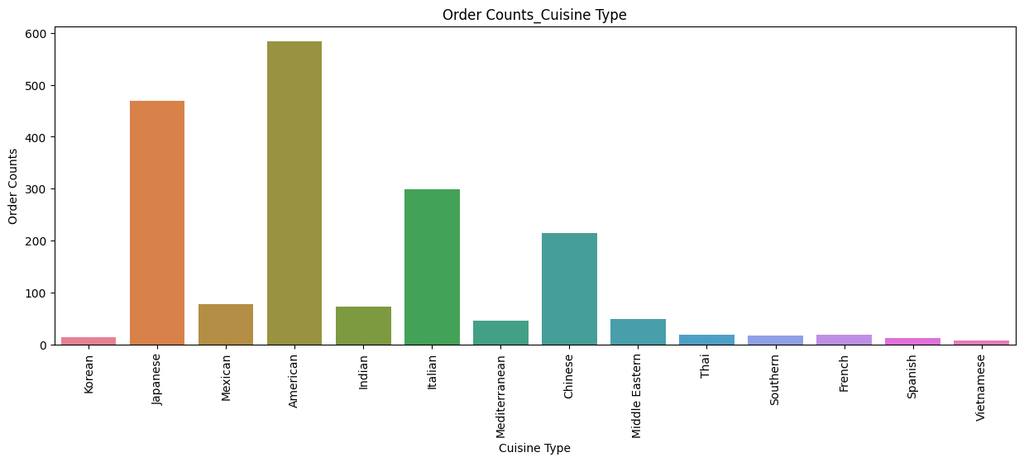

```python
# Countplot_Cuisine_type
plt.figure(figsize = (15,5))
sns.countplot(data = foodhub, x = 'cuisine_type', hue='cuisine_type')
plt.xlabel('Cuisine Type')
plt.ylabel('Order Counts')
plt.xticks(rotation=90)
plt.title('Order Counts_Cuisine Type')
plt.show()
plt.savefig('order_counts_cuisine_type.png')
```

##### Observations:

- Number of unique values in the cuisine_type column is 14
- The most frequent cuisine type is American followed by Japanese, Italian and Chinese.
- Vietnamese, Spanish cuisine types are least in demand.

```python
# 5th variable: cost_of_the_order
foodhub['cost_of_the_order'].nunique()
```

```
312
```

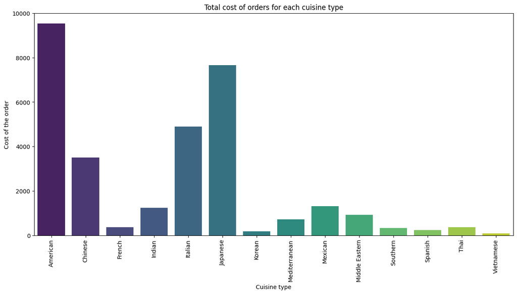

```python
# Calculating the total cost of orders for each cuisine type
total_cost_of_order = foodhub.groupby('cuisine_type')['cost_of_the_order'].sum().reset_index()

# Bar plot
plt.figure(figsize=(15, 7))
sns.barplot(data=total_cost_of_order, x='cuisine_type', y='cost_of_the_order', hue= 'cuisine_type', palette='viridis')
plt.xlabel('Cuisine type')
plt.ylabel('Cost of the order')
plt.title('Total cost of orders for each cuisine type')
plt.xticks(rotation=90)
plt.show()
total_cost = float(foodhub['cost_of_the_order'].sum())
plt.savefig('total_cost.png')
```

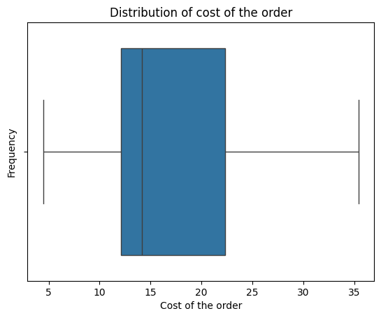

```python
# Boxplot
sns.boxplot(data=foodhub, x='cost_of_the_order')
plt.xlabel('Cost of the order')
plt.ylabel('Frequency')
plt.title('Distribution of cost of the order')
plt.show()
plt.savefig('boxplot_cost_of_the_order.png')
```

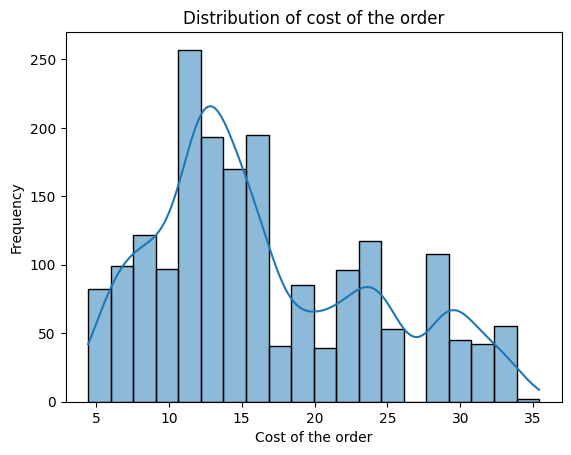

```python
# Histplot
sns.histplot(data=foodhub, x='cost_of_the_order', bins=20, kde=True)
plt.xlabel('Cost of the order')
plt.ylabel('Frequency')
plt.title('Distribution of cost of the order')
plt.show()
plt.savefig('histplot_cost_of_the_order.png')
```

### Observations:

- The average cost of the order is greater than the median cost indicating that the distribution for the cost of the order is right-skewed.
- The mode of the distribution indicates that a large chunk of people prefer to order food that costs around 10-12 dollars.
- There are few orders with that cost more than 30 dollars. These orders might be for some expensive meals.
- There are no outliers.

```python
# 6th variable: day_of_the_week
foodhub['day_of_the_week'].nunique()
foodhub['day_of_the_week'].value_counts()
```

| day_of_the_week | count |
| --- | --- |
| Weekend | 1351 |
| Weekday | 547 |

**dtype:** int64

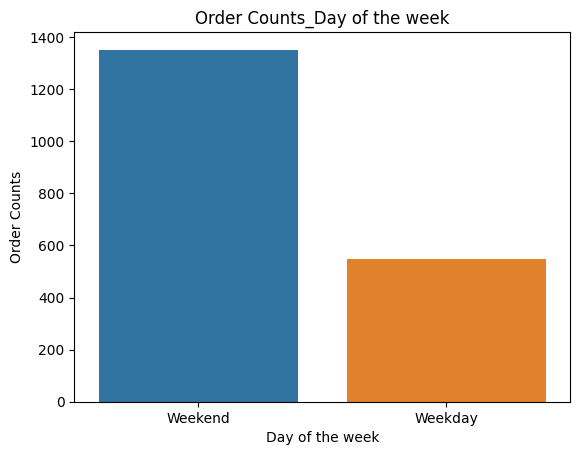

```python
# countplot_day_of_the_week
sns.countplot(data = foodhub, x = 'day_of_the_week', hue= 'day_of_the_week')
plt.xlabel('Day of the week')
plt.ylabel('Order Counts')
plt.title('Order Counts_Day of the week')
plt.show()
plt.savefig('order_counts_day_of_the_week.png')
```

```python
# 7th variable: rating
foodhub['rating'].nunique()
```

```
4
```

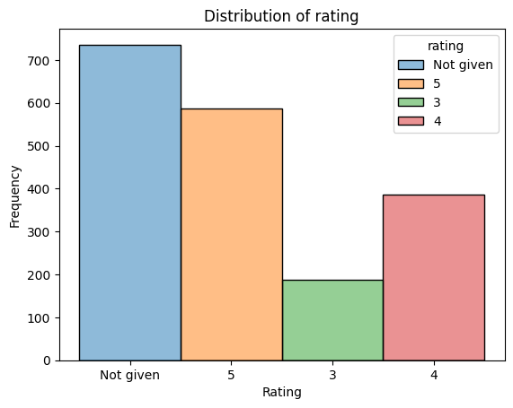

```python
# Histplot_rating
sns.histplot(data=foodhub, x='rating', hue= 'rating', bins=20, kde=True)
plt.xlabel('Rating')
plt.ylabel('Frequency')
plt.title('Distribution of rating')
plt.show()
plt.savefig('histplot_rating.png')
```

### Observations:

- Most of the customers (more than 700) have "Not given" any rating.
- Around 600 gave 5 rating, 200 gave 3 rating followed by 4 rating by aroung 400 customers.

```python
# 8th variable: food_preparation_time
foodhub['food_preparation_time'].nunique()
```

```
16
```

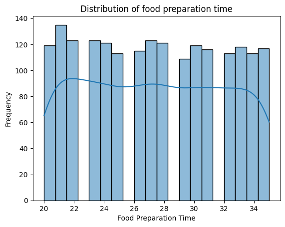

```python
# Histplot_food_preparation_time
sns.histplot(data=foodhub, x='food_preparation_time', bins=20, kde=True)
plt.xlabel('Food Preparation Time')
plt.ylabel('Frequency')
plt.title('Distribution of food preparation time')
plt.show()
plt.savefig('histplot_food_preparation_time.png')
```

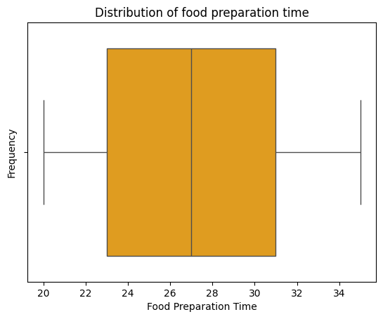

```python
# Boxplot_food_preparation_time
sns.boxplot(data=foodhub, x='food_preparation_time', showfliers= True, color= 'orange')
plt.xlabel('Food Preparation Time')
plt.ylabel('Frequency')
plt.title('Distribution of food preparation time')
plt.show()
plt.savefig('boxplot_food_preparation_time.png')
```

### Observations:

- The distribution is nearly symmetrical as the average food preparation time  
  is almost equal to the median food preparation time.
- The food preparation time is evenly distributed between 20 and 35 minutes.
- There are no outliers in this column.

```python
# 9th variable: delivery_time
foodhub['delivery_time'].nunique()
```

```
19
```

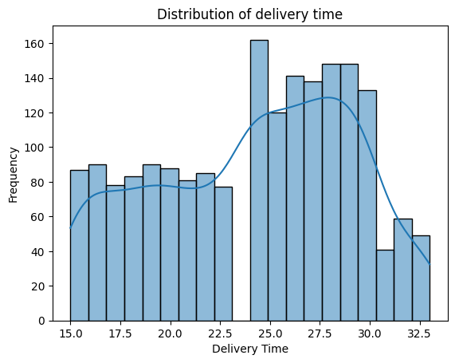

```python
# Histplot_delievery_time
sns.histplot(data=foodhub, x='delivery_time', bins=20, kde=True)
plt.xlabel('Delivery Time')
plt.ylabel('Frequency')
plt.title('Distribution of delivery time')
plt.show()
plt.savefig('histplot_delievery_time.png')
```

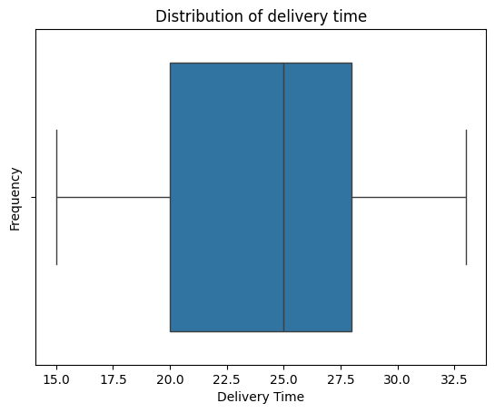

```python
# Boxplot_delievery_time
sns.boxplot(data=foodhub, x='delivery_time')
plt.xlabel('Delivery Time')
plt.ylabel('Frequency')
plt.title('Distribution of delivery time')
plt.show()
plt.savefig('boxplot_delievery_time.png')
```

### Observations:

- The average delivery time is a bit smaller than the median delivery time indicating that the distribution is a bit left-skewed.
- Comparatively more number of orders have delivery time between 24 and 30 minutes.
- There are no outliers in this column.

### **Question 7**: Which are the top 5 restaurants in terms of the number of orders received? [1 mark]

```python
# top 5 restaurants in terms of the number of orders received?
foodhub['restaurant_name'].value_counts()[:5]
```

| restaurant_name | count |
| --- | --- |
| Shake Shack | 219 |
| The Meatball Shop | 132 |
| Blue Ribbon Sushi | 119 |
| Blue Ribbon Fried Chicken | 96 |
| Parm | 68 |

**dtype:** int64

#### Observations:

- Top 5 popular restaurants that have received the highest number of orders  
  are:
1. Shake Shack received 219 orders.
2. The Meatball Shop has received 132 orders.
3. Blue Ribbon Sushi has received 119 orders.
4. Blue Ribbon Fried Chicken has received 96 orders.
5. Parm has received 68 orders.

### **Question 8**: Which is the most popular cuisine on weekends? [1 mark]

```python
# most popular cuisine on weekends
pop_weekend_cuisine = foodhub[foodhub['day_of_the_week'] == 'Weekend']
pop_weekend_cuisine['cuisine_type'].value_counts()
```

| cuisine_type | count |
| --- | --- |
| American | 415 |
| Japanese | 335 |
| Italian | 207 |
| Chinese | 163 |
| Mexican | 53 |
| Indian | 49 |
| Mediterranean | 32 |
| Middle Eastern | 32 |
| Thai | 15 |
| French | 13 |
| Korean | 11 |
| Southern | 11 |
| Spanish | 11 |
| Vietnamese | 4 |

**dtype:** int64

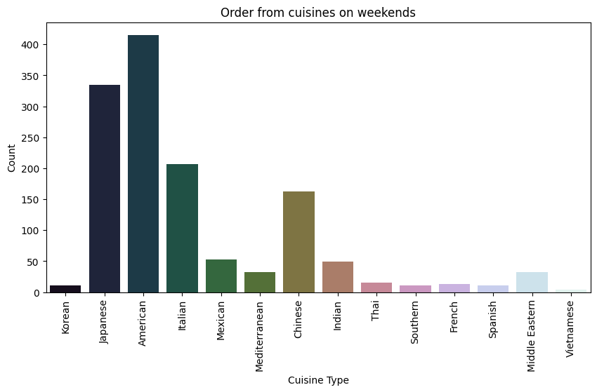

```python
# countplot_cuisine_type
plt.figure(figsize=(10, 5))
df_weekend = foodhub[foodhub['day_of_the_week'] == 'Weekend']
sns.countplot(data=df_weekend, x='cuisine_type', palette = 'cubehelix')
plt.xlabel('Cuisine Type')
plt.ylabel('Count')
plt.title('Order from cuisines on weekends')
plt.xticks(rotation=90)
plt.show()
plt.savefig('countplot_cuisine_type.png')
```

### **Question 9**: What percentage of the orders cost more than 20 dollars? [2 marks]

```python
# The percentage of the orders cost more than 20 dollars
food_more= foodhub[foodhub ['cost_of_the_order']> 20]
print('The number of total orders that cost above 20 dollars is:', len(food_more))
print('The number of total orders is:', len(foodhub))
percentage = (len(food_more)/len(foodhub))*100
print('The percentage of the orders cost more than 20 dollars is:', len(food_more)/len(foodhub)*100,'%')
print("Percentage of orders above 20 dollars:", round(percentage, 2),'%') # Rounding of the percentage value upto 2
```

```
The number of total orders that cost above 20 dollars is: 555
The number of total orders is: 1898
The percentage of the orders cost more than 20 dollars is: 29.24130663856691 %
Percentage of orders above 20 dollars: 29.24 %
```

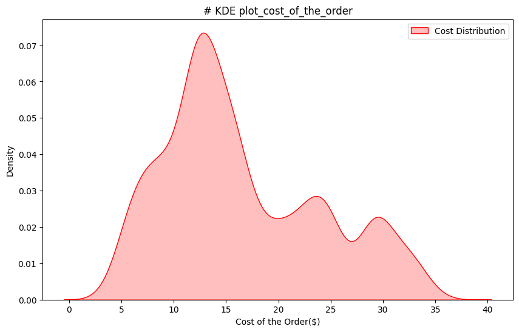

```python
# KDE plot_cost_of_the_order
plt.figure(figsize=(10, 6))
sns.kdeplot(data=foodhub, x='cost_of_the_order', fill=True, color='red', label='Cost Distribution')
plt.xlabel('Cost of the Order($)')
plt.ylabel('Density')
plt.title('# KDE plot_cost_of_the_order')
plt.legend()
plt.show()
plt.savefig('KDE_plot_cost_of_the_order.png')
```

#### Observations:

- Percentage of orders abomore than 20 dollars is 29.24 %
- The number of total orders that cost above 20 dollars is: 555

### **Question 10**: What is the mean order delivery time? [1 mark]

```python
# mean order delievery time
mean_delivery_time= foodhub['delivery_time'].mean().round(2)
mean_delivery_time
```

```
24.16
```

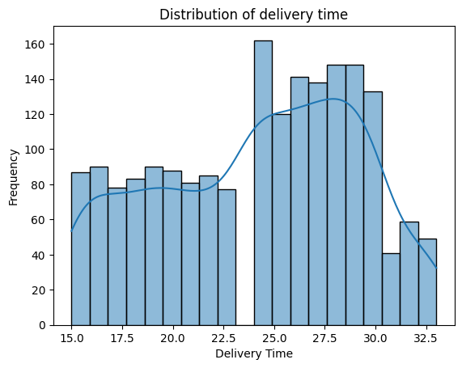

```python
# Histplot for mean delivery time
sns.histplot(data=foodhub, x='delivery_time', bins=20, kde=True)
plt.xlabel('Delivery Time')
plt.ylabel('Frequency')
plt.title('Distribution of delivery time')
plt.show()
plt.savefig('histplot_delievery_time.png')
```

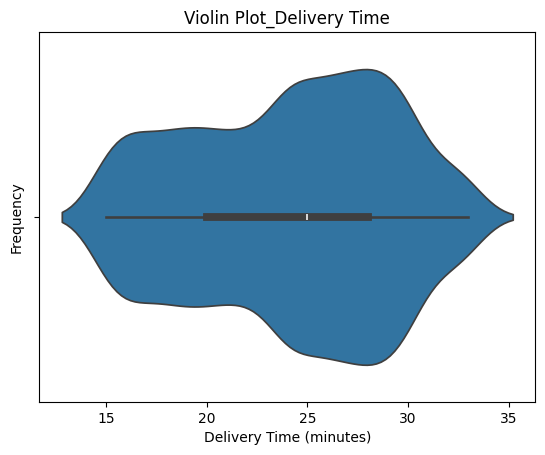

[figure not shown]

```python
# Plot a violin plot
sns.violinplot(data=foodhub, x='delivery_time')
plt.title('Violin Plot_Delivery Time')
plt.xlabel('Delivery Time (minutes)')
plt.ylabel('Frequency')
plt.show()
plt.savefig('violinplot_delievery_time.png')

# Adding a line for mean delivery_time
plt.axvline(mean_delivery_time, color='red', linestyle='--', label='Mean Delivery Time')
plt.legend()
plt.show()
plt.savefig('violinplot_mean_delievery_time.png')
```

[figure not shown]

```python
# Plotting the KDE plot_Delievery_Time
plt.figure(figsize=(10, 5))
sns.kdeplot(data=foodhub, x='delivery_time', fill=True, color='Green', label='Delivery Time Distribution')

# Adding a vertical line at the mean to show the exact value
plt.xlabel('Delivery Time (minutes)')
plt.ylabel('Density')
plt.title('KDE Plot_Delivery Time')
plt.axvline(mean_delivery_time, color='red', linestyle='--', label='Mean Delivery Time ({mean_delivery_time:.2f} minutes)')
plt.legend()
plt.show()
plt.savefig('KDE_plot_mean_delievery_time.png')
```

#### Observations:

- Mean delivery time of orders is 24.16 minutes

### **Question 11:** The company has decided to give 20% discount vouchers to the top 3 most frequent customers. Find the IDs of these customers and the number of orders they placed. [1 mark]

```python
# top 3 most frequent customers
top_customers= foodhub['customer_id'].value_counts()[:3]
top_customers
```

| customer_id | count |
| --- | --- |
| 52832 | 13 |
| 47440 | 10 |
| 83287 | 9 |

**dtype:** int64

### Observations

- customer_id: 52832, 47440, and 83287 are the top three most frequent customers with 13, 10, and 9 orders, respectively.

### **Question 12**: Perform a multivariate analysis to explore relationships between the important variables in the dataset. (It is a good idea to explore relations between numerical variables as well as relations between numerical and categorical variables) [10 marks]

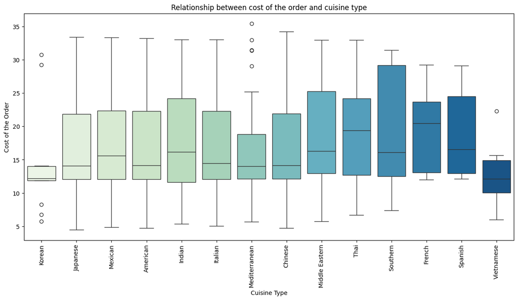

```python
# Relationship between cost of the order and cuisine type
plt.figure(figsize=(15,7))
sns.boxplot(x = "cuisine_type", y = "cost_of_the_order", data = foodhub, hue= 'cuisine_type', palette='GnBu')
plt.xticks(rotation = 90)
plt.xlabel('Cuisine Type')
plt.ylabel('Cost of the Order')
plt.title('Relationship between cost of the order and cuisine type')
plt.show()
plt.savefig('boxplot_cost_of_the_order_cuisine_type.png')
```

```python
# checking mean and median of the costs for cuisine types
print('Mean values\n', foodhub.groupby('cuisine_type')['cost_of_the_order'].mean().sort_values(ascending=False).round(2))
```

```
Mean values
 cuisine_type
French            19.79
Southern          19.30
Thai              19.21
Spanish           18.99
Middle Eastern    18.82
Mexican           16.93
Indian            16.92
Italian           16.42
American          16.32
Chinese           16.31
Japanese          16.30
Mediterranean     15.47
Korean            14.00
Vietnamese        12.88
Name: cost_of_the_order, dtype: float64
```

```python
print('Median values\n',foodhub.groupby('cuisine_type')['cost_of_the_order'].median().sort_values(ascending=False).round(2))
```

```
Median values
 cuisine_type
French            20.47
Thai              19.35
Spanish           16.52
Middle Eastern    16.30
Indian            16.15
Southern          16.11
Mexican           15.57
Italian           14.48
American          14.12
Chinese           14.12
Japanese          14.07
Mediterranean     14.00
Korean            12.18
Vietnamese        12.13
Name: cost_of_the_order, dtype: float64
```

### Observations:

- The top five cuisine types with the highest costs are French, Southern, Thai, Spanish, and Middle Eastern.
- The boxplots for Italian, American, Chinese, Japanese cuisines are quite similar. This indicates that the quartile costs for these cuisines are quite similar.
- Vietnamese and Korean cuisines cost less compared to other cuisines.
- Outliers are present for the cost of Korean, Mediterranean and Vietnamese cuisines.
- French and Spanish cuisines are costlier compared to other cuisines.
- The mean and median value for the cost of cuisine type is around 12 to 20 dollars.

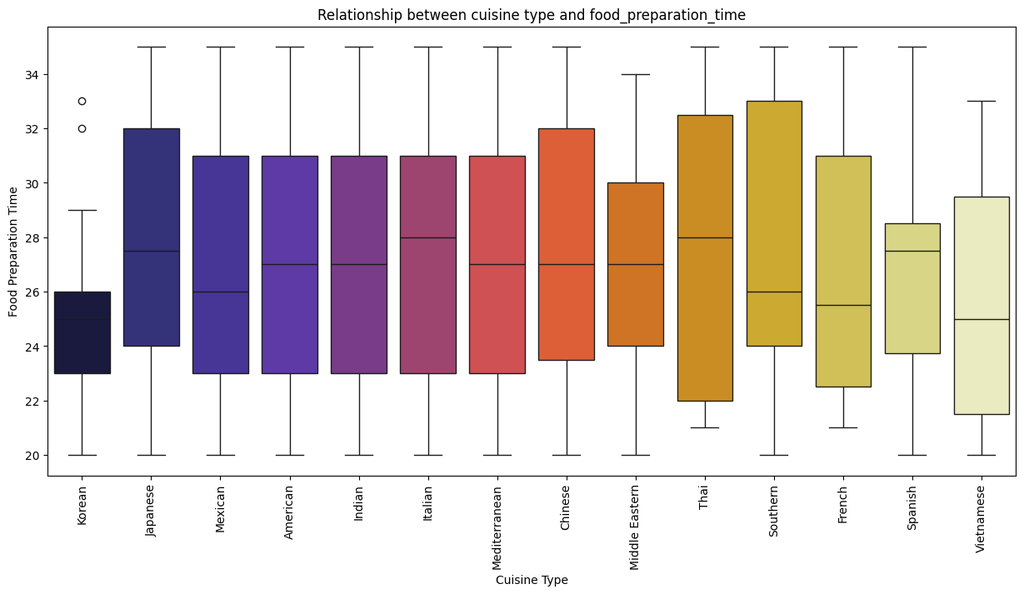

```python
# Relationship between cuisine type and food_preparation_time
plt.figure(figsize=(15,7))
sns.boxplot(x = "cuisine_type", y = "food_preparation_time", data = foodhub, hue='cuisine_type', palette = 'CMRmap')
plt.xticks(rotation = 90)
plt.xlabel('Cuisine Type')
plt.ylabel('Food Preparation Time')
plt.title('Relationship between cuisine type and food_preparation_time')
plt.show()
plt.savefig('boxplot_cuisine_type_food_preparation_time.png')
```

```python
# checking mean and median of the food preparation time for cuisine types
print('Mean values\n',foodhub.groupby('cuisine_type')['food_preparation_time'].mean().sort_values(ascending=False).round(2))
```

```
Mean values
 cuisine_type
Southern          27.59
Chinese           27.51
Japanese          27.51
Italian           27.48
American          27.44
Thai              27.32
Indian            27.11
Mediterranean     27.00
Spanish           26.92
French            26.89
Mexican           26.73
Middle Eastern    26.67
Vietnamese        25.71
Korean            25.46
Name: food_preparation_time, dtype: float64
```

```python
print('Median values\n',foodhub.groupby('cuisine_type')['food_preparation_time'].median().sort_values(ascending=False).round(2))
```

```
Median values
 cuisine_type
Italian           28.0
Thai              28.0
Japanese          27.5
Spanish           27.5
American          27.0
Chinese           27.0
Indian            27.0
Mediterranean     27.0
Middle Eastern    27.0
Mexican           26.0
Southern          26.0
French            25.5
Korean            25.0
Vietnamese        25.0
Name: food_preparation_time, dtype: float64
```

### Observations:

- Food preparation time is extremely steady for a most cuisine_types.
- Korean cuisine gets ready faster as compared to the other cuisines.
- The mean value for food preparation time is 24 to 28 minutes, and median  
  lies between 24 and 30 minutes for all the cuisines.
- Outliers are present for the food preparation time of Korean cuisine.

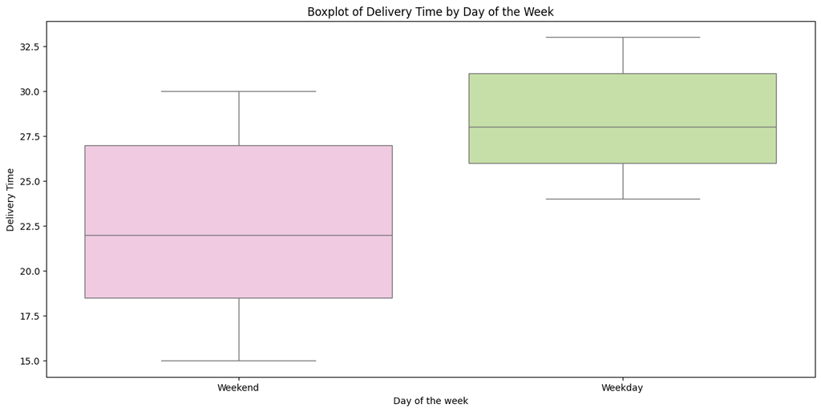

```python
# Relationship between day_of_the_week and delivery_time
plt.figure(figsize=(15,7))
sns.boxplot( data = foodhub, x = "day_of_the_week", y = "delivery_time", hue= 'day_of_the_week' , palette = 'PiYG')
plt.xlabel('Day of the week')
plt.ylabel('Delivery Time')
plt.title('Boxplot of Delivery Time by Day of the Week')
plt.show()
plt.savefig('boxplot_delivery_time_day_of_the_week.png')
```

```python
# checking mean and median of the day_of_the_week and Delivery_time
print('Mean values\n',foodhub.groupby('day_of_the_week')['delivery_time'].mean().sort_values(ascending=False).round(2))
```

```
Mean values
 day_of_the_week
Weekday    28.34
Weekend    22.47
Name: delivery_time, dtype: float64
```

```python
print('Median values\n',foodhub.groupby('day_of_the_week')['delivery_time'].median().sort_values(ascending=False).round(2))
```

```
Median values
 day_of_the_week
Weekday    28.0
Weekend    22.0
Name: delivery_time, dtype: float64
```

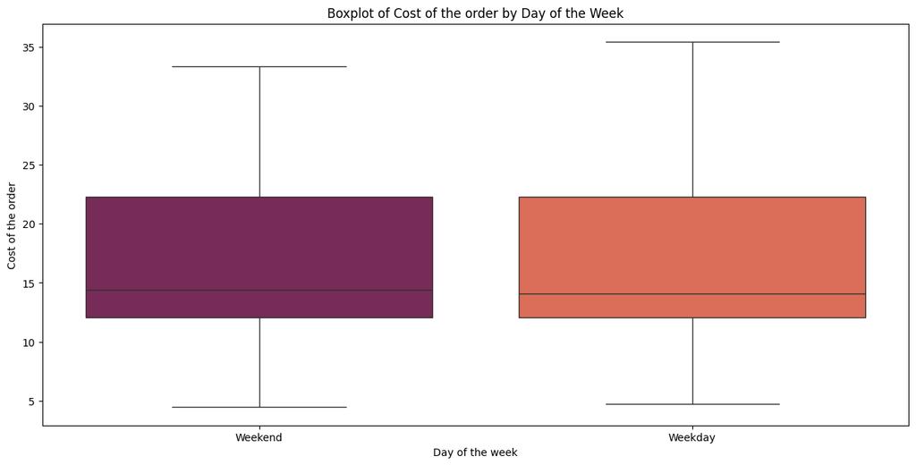

```python
# Relation between Day_of_the_week and Cost_of_the_Order
plt.figure(figsize=(15,7))
sns.boxplot(data = foodhub, x = "day_of_the_week", y = "cost_of_the_order", hue= 'day_of_the_week', palette = 'rocket')
plt.xlabel('Day of the week')
plt.ylabel('Cost of the order')
plt.title('Boxplot of Cost of the order by Day of the Week')
plt.show()
plt.savefig('boxplot_cost_of_the_order_day_of_the_week.png')
```

### Observations:

- The delivery time for all the orders over the weekends is less i.e. **22.47**, as compared to weekdays i.e. **28.34**.
- The median values are 28 on weekdays and 22 on weekends.

```python
## checking mean and median of the day_of_the_week and Cost_of_the_order
print('Mean values\n',foodhub.groupby('day_of_the_week')['cost_of_the_order'].mean().sort_values(ascending=False).round(2))
```

```
Mean values
 day_of_the_week
Weekend    16.57
Weekday    16.31
Name: cost_of_the_order, dtype: float64
```

```python
print('Median values\n',foodhub.groupby('day_of_the_week')['cost_of_the_order'].median().sort_values(ascending=False).round(2))
```

```
Median values
 day_of_the_week
Weekend    14.41
Weekday    14.07
Name: cost_of_the_order, dtype: float64
```

### Observations:

- The mean and median values for the cost of the orders are relatively close to one another.

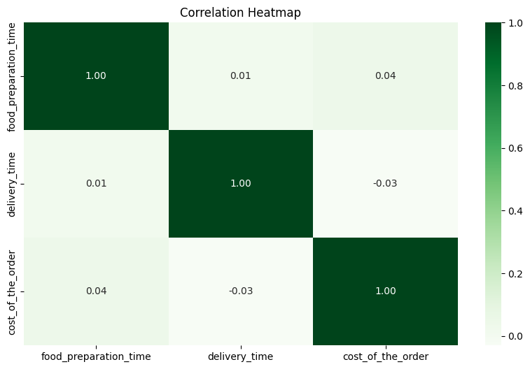

```python
# Heatmap Plot between food_preparation_time, delivery_time, cost_of_the_order
food_time_cost = ['food_preparation_time', 'delivery_time', 'cost_of_the_order']
plt.figure(figsize=(10, 6))
sns.heatmap(foodhub[food_time_cost].corr(), annot=True, cmap='Greens', fmt='.2f')
plt.title('Correlation Heatmap')
plt.show()
plt.savefig('heatmap_correlation.png')
```

### Observation:

- There is no correlation between cost of the order, delivery time and food preparation time.

```python
# relation between Restaurant_name and Cost_of_the_Order
foodhub.groupby(['restaurant_name'])['cost_of_the_order'].sum().sort_values(ascending = False).head(14)
```

| restaurant_name | cost_of_the_order |
| --- | --- |
| Shake Shack | 3579.53 |
| The Meatball Shop | 2145.21 |
| Blue Ribbon Sushi | 1903.95 |
| Blue Ribbon Fried Chicken | 1662.29 |
| Parm | 1112.76 |
| RedFarm Broadway | 965.13 |
| RedFarm Hudson | 921.21 |
| TAO | 834.50 |
| Han Dynasty | 755.29 |
| Blue Ribbon Sushi Bar & Grill | 666.62 |
| Rubirosa | 660.45 |
| Sushi of Gari 46 | 640.87 |
| Nobu Next Door | 623.67 |
| Five Guys Burgers and Fries | 506.47 |

**dtype:** float64

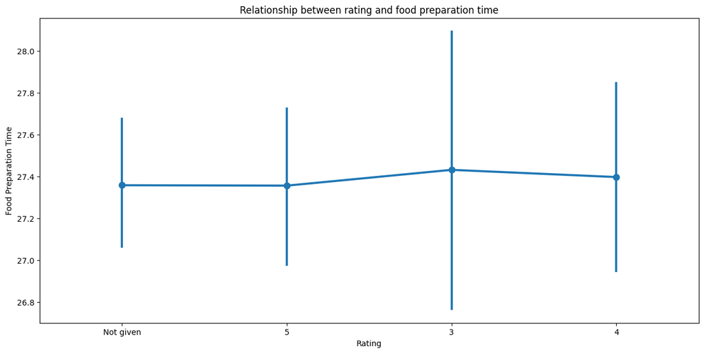

```python
# Relationship between rating and food preparation time
plt.figure(figsize=(15, 7))
sns.pointplot(data = foodhub, x = 'rating', y = 'food_preparation_time')
plt.xlabel('Rating')
plt.ylabel('Food Preparation Time')
plt.title('Relationship between rating and food preparation time')
plt.show()
plt.savefig('pointplot_rating_food_preparation_time.png')
```

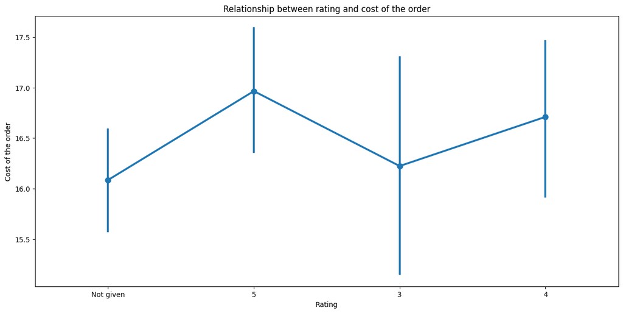

```python
# Relationship between rating and cost of the order
plt.figure(figsize=(15, 7))
sns.pointplot(data= foodhub, x = 'rating', y = 'cost_of_the_order')
plt.xlabel('Rating')
plt.ylabel('Cost of the order')
plt.title('Relationship between rating and cost of the order')
plt.show()
plt.savefig('pointplot_rating_cost_of_the_order.png')
```

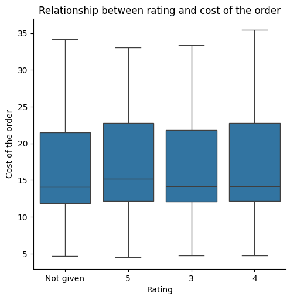

```python
# catplot between rating and cost_of_the_order
sns.catplot(data= foodhub, x = 'rating', y = 'cost_of_the_order', kind = 'box')
plt.xlabel('Rating')
plt.ylabel('Cost of the order')
plt.title('Relationship between rating and cost of the order')
plt.show()
plt.savefig('catplot_rating_cost_of_the_order.png')
```

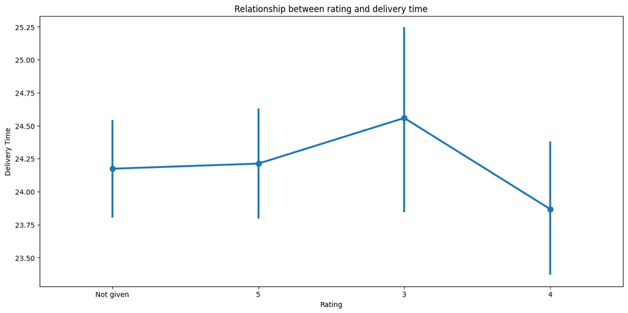

```python
# Relationship between rating and delivery time_pointplot
plt.figure(figsize=(15, 7))
sns.pointplot(data= foodhub, x = 'rating', y = 'delivery_time')
plt.xlabel('Rating')
plt.ylabel('Delivery Time')
plt.title('Relationship between rating and delivery time')
plt.show()
plt.savefig('pointplot_rating_delivery_time.png')
```

### **Question 13:** The company wants to provide a promotional offer in the advertisement of the restaurants. The condition to get the offer is that the restaurants must have a rating count of more than 50 and the average rating should be greater than 4. Find the restaurants fulfilling the criteria to get the promotional offer. [3 marks]

```python
# Filter out the restaurants with rating from the dataset
rated_restaurant= foodhub[foodhub['rating'] != 'Not given'].copy()

# Convert datatype of rating column from object to integer
rated_restaurant['rating'] = rated_restaurant['rating'].astype('int')

# Create a new dataframe with the restaurant names with their rating counts
rating_count = rated_restaurant.groupby(['restaurant_name'])['rating'].count().sort_values(ascending = False).reset_index()
rating_count.head()
```

|  | restaurant_name | rating |
| --- | --- | --- |
| 0 | Shake Shack | 133 |
| 1 | The Meatball Shop | 84 |
| 2 | Blue Ribbon Sushi | 73 |
| 3 | Blue Ribbon Fried Chicken | 64 |
| 4 | RedFarm Broadway | 41 |

```python
# Find restaurant names that have rating count more than 50
rest_names = rating_count[rating_count['rating'] > 50]['restaurant_name']
# filter to get the data of restaurants that have rating count more than 50
foodhub_mean_4 = rated_restaurant[rated_restaurant['restaurant_name'].isin(rest_names)].copy()
# find the mean rating of the restaurants
foodhub_mean_4.groupby(foodhub_mean_4['restaurant_name'])['rating'].mean().sort_values(ascending = False).reset_index()
```

|  | restaurant_name | rating |
| --- | --- | --- |
| 0 | The Meatball Shop | 4.511905 |
| 1 | Blue Ribbon Fried Chicken | 4.328125 |
| 2 | Shake Shack | 4.278195 |
| 3 | Blue Ribbon Sushi | 4.219178 |

#### Observations:

- On the basis of above analysis, the restaurants fulfilling the criteria to get the promotional offer are:
1. The Meatball Shop
2. Blue Ribbon Fried Chicken
3. Shake Shack and
4. Blue Ribbon Sushi

### **Question 14:** The company charges the restaurant 25% on the orders having cost greater than 20 dollars and 15% on the orders having cost greater than 5 dollars. Find the net revenue generated by the company across all orders. [3 marks]

```python
#function to determine the net revenue
def compute_rev(x):
    if x > 20:
        return x*0.25
    elif x > 5:
        return x*0.15
    else:
        return x*0

foodhub['Revenue'] = foodhub['cost_of_the_order'].apply(compute_rev)
foodhub.head()
```

|  | order_id | customer_id | restaurant_name | cuisine_type | cost_of_the_order | day_of_the_week | rating | food_preparation_time | delivery_time | Revenue |
| --- | --- | --- | --- | --- | --- | --- | --- | --- | --- | --- |
| 0 | 1477147 | 337525 | Hangawi | Korean | 30.75 | Weekend | Not given | 25 | 20 | 7.6875 |
| 1 | 1477685 | 358141 | Blue Ribbon Sushi Izakaya | Japanese | 12.08 | Weekend | Not given | 25 | 23 | 1.8120 |
| 2 | 1477070 | 66393 | Cafe Habana | Mexican | 12.23 | Weekday | 5 | 23 | 28 | 1.8345 |
| 3 | 1477334 | 106968 | Blue Ribbon Fried Chicken | American | 29.20 | Weekend | 3 | 25 | 15 | 7.3000 |
| 4 | 1478249 | 76942 | Dirty Bird to Go | American | 11.59 | Weekday | 4 | 25 | 24 | 1.7385 |

```python
# get the Net revenue and print it
Net_revenue = foodhub['Revenue'].sum()
print('Net Revenue is:', Net_revenue, 'dollars.')
```

```
Net Revenue is: 6166.303 dollars.
```

#### Observations:

- The net revenue generated by the company across all orders is 6166.303 dollars.

### **Question 15:** The company wants to analyze the total time required to deliver the food. What percentage of orders take more than 60 minutes to get delivered from the time the order is placed? (The food has to be prepared and then delivered.) [2 marks]

```python
# Add a new column to foodhub dataset that stores total delivery time
foodhub['total_time'] = foodhub['food_preparation_time'] + foodhub['delivery_time']

# Finding the oders that takes more than 60 minutes
f_60 = foodhub[foodhub['total_time'] > 60]

# Calculate the percentage of f_60
print ('The percentage of orders that have more than 60 minutes of total delivery time is', round(f_60.shape[0] / foodhub.shape[0] * 100, 2),'%')
```

```
The percentage of orders that have more than 60 minutes of total delivery time is 10.54 %
```

#### Observations:

- After the customer places an order, 10.54% of the orders take more than 60 minutes to deliver the food.

### **Question 16:** The company wants to analyze the delivery time of the orders on weekdays and weekends. How does the mean delivery time vary during weekdays and weekends? [2 marks]

```python
# Finding the difference between the mean of delivery time on weekdays and weekends

df_weekend = foodhub[foodhub['day_of_the_week'] == 'Weekend']
df_weekday = foodhub[foodhub['day_of_the_week'] == 'Weekday']

mean_delivery_weekday = df_weekday['delivery_time'].mean()
print('The mean of weekday delivery is:', mean_delivery_weekday)
mean_delivery_weekend = df_weekend['delivery_time'].mean()
print('The mean of weekend delivery is:', mean_delivery_weekend)
difference_mean = mean_delivery_weekday- mean_delivery_weekend
difference_mean

# Printing the average delievery time on weekdays & weekends with their difference
print('The average delivery time on weekdays is around', round(mean_delivery_weekday, 2), 'minutes')
print('The average delivery time on weekends is around', round(mean_delivery_weekend, 2), 'minutes')
print('Difference between average delivery time on weekdays and weekends is around', round(difference_mean,2), 'minutes')
```

```
The mean of weekday delivery is: 28.340036563071298
The mean of weekend delivery is: 22.4700222057735
The average delivery time on weekdays is around 28.34 minutes
The average delivery time on weekends is around 22.47 minutes
Difference between average delivery time on weekdays and weekends is around 5.87 minutes
```

#### Observations:

- The mean of weekday delivery is: 28.340036563071298
- The mean of weekend delivery is: 22.4700222057735
- The average delivery time on weekdays is around 28.34 minutes.
- The average delivery time on weekends is around 22.47 minutes.
- Difference between average delivery time on weekdays and weekends is around 5.87 minutes.

### Conclusion and Recommendations

### **Question 17:** What are your conclusions from the analysis? What recommendations would you like to share to help improve the business? (You can use cuisine type and feedback ratings to drive your business recommendations.) [6 marks]

### Conclusions:

The Foodhub dataset provides valuable insights into customer ordering behavior and restaurant performance.

Recommendations:

1. Focus on American Cuisine: As the American cuisine is the most popular one, so the restaurants should consider offerings on american cuisine, especially on weekends when demand is high. This could include seasonal specials or themed promotions to attract more customers.
2. Korean Cuisine: KAs per the analysis, Korean cuisine also showing faster service times, enhancing offerings in this cuisine also improve the efficiency in their market. Also, highlighting quick delivery options could attract customers looking for speedy meals.
3. Weekend Promotions: Leverage the shorter delivery times on weekends by introducing special weekend promotions or loyalty programs that encourage repeat orders during this peak period.
4. Weekday Strategies: Since weekdays see lower order volumes, restaurants could consider discounts to boost customer engagement during weekdays. Options like weekday specials could attract more customers/orders.
5. Customer Feedback: To better understand the factors influencing customer satisfaction, restaurants should implement feedback forms. Gathering informations on customer preferences can help in setting up the menu to improve better food and service quality.
6. Cancellation Data: Data collection on order cancellations and reasons, which can help identify issues in the order process.

By implementing these strategies, restaurants can enhance their offerings, improve customer satisfaction, and capitalize on the insights gained from the Foodhub dataset.